# Optimal Contract Under Limited Efforts

Hongyi Xu - Stockholm School of Economics

6/2/2022

> [Template Link Guidance](https://www.sciencedirect.com/science/article/pii/S2667145X21000171) & [Bookdown Themes](https://juba.github.io/rmdformats/)

#### Preface

Following the illustration of the “Optimal Contract Under Diversification”, we can see that diversification provides great benefits for the entrepreneur to mitigate credit rationing, although not able to fully eliminate it. The main reason is that such structure, denoted as cross-pledging in Tirole (2006), reduces the total amount of agency rent and increase the pledgeable income. This benefit supports the corporate acquisition and diversification. But in reality, we also see many corporations, even big corporations such as HSBC and Johnson & Johnson, are considering to spin off these days. So, why they choose to do that?

Here we list some main takeaway for the spin-offs:

- A spin-off is the creation of an independent company through the sale or distribution of new shares of an existing business or division of a parent company.
- The spun-off companies are expected to be worth more as independent entities than as parts of a larger business.
- When a corporation spins off a business unit that has its own management structure, it sets it up as an independent company under a renamed business entity.

And from here, we can see the main driver of a spin-off decision is whether the collective value of two entities is greater than the value of the initial big corporation. From [Ank and Walker (1999)](https://www.sciencedirect.com/science/article/pii/S0929119906000071#bib23), we can see that

> Previous evidence suggests that the decision to spin-off a division is a value-increasing event if the spin-off decreases the firm’s industrial scope ([Daley et al., 1997](https://www.sciencedirect.com/science/article/pii/S0929119906000071#bib12)). The sources of this value increase include non-mutually exclusive explanations such as improved efficiency of capital allocation subsequent to the spinoffs ([Ahn and Denis, 2004](https://www.sciencedirect.com/science/article/pii/S0929119906000071#bib1)), tax and regulatory benefits ([Schipper and Smith, 1983](https://www.sciencedirect.com/science/article/pii/S0929119906000071#bib34)), improved contracting ([Schipper and Smith, 1983](https://www.sciencedirect.com/science/article/pii/S0929119906000071#bib34)), and decreased information asymmetry ([Krishnaswami and Subramaniam, 1999](https://www.sciencedirect.com/science/article/pii/S0929119906000071#bib23)).

Based upon previous theories, this project wants to model up an model to analyse the financial constraints under the limited ability of the entrepreneur. I want to add this limited ability as a combination of moral hazard and adverse selection and present when such a spin-off can reduce the financial constraints and create additional value for shareholders.

#### 1. Framework Setup

Like in the previous file “[TCP_Project_Premodel](https://livehhsse-my.sharepoint.com/:u:/g/personal/65570_student_hhs_se/EaCsv-LhGS1Ilgb0saOm3PYBnBy6jn5yh53JSu_ppORNpA?e=A0bpX3)”, we consider the following setting. The risk-neutral entrepreneur now still has two independent, identical projects. Each project generates a cash flow $r = R$ under the project success at time t, with probability $p$ conditional the effort level $E$, and generates nothing if the project fails. Meanwhile, if the entrepreneur exerts high effects on the project, i.e. $E = 1$, then the probability of success of this project is $p = p_H \in (0,1]$. Otherwise, $p = p_L \in [0,1)$ if the entrepreneur shirks (exerts low effect) on the project.

We also assume $p_H > p_L$. And same as before, we still consider the case that the entrepreneur can contribute asset amount $A$ in each project and needs external financing to start the project, which requires total investment $I$. We also assume that there are infinitely many risk-neutral investors and the entrepreneur has the bargaining power. The private benefit for the entrepreneur shirking on each project is $B$. Meanwhile, we still hold the assumption that the NPV of each project is positive if the entrepreneur exerts effort on the project, and that is negative if the entrepreneur shirks. i.e. $p_H R > I > p_L R$.

##### 1.1 Additional Assumptions

Different from the previous case, we have several new assumptions:

- The each project will no longer face financial constraints individually. i.e.
  $$A \geq \bar{A} = I - p_H[R - \frac{B}{\Delta p}]$$
  Ceteris paribus, this assumption guarantees that the combined project can obtain external financing based on our analyses in the [previous document](https://livehhsse-my.sharepoint.com/:u:/g/personal/65570_student_hhs_se/EaCsv-LhGS1Ilgb0saOm3PYBnBy6jn5yh53JSu_ppORNpA?e=A0bpX3).
- We bring adverse selection into the model. We assume that there are two types of entrepreneurs - Good and Bad. The first type (Good) is the one without effort levels as in the previous example, who can exerts efforts on all projects. The second type (Bad), who is also the interest of this project, can only exerts limited efforts and there is an uppper bound for the maximum level of efforts $\bar{E}$ can be exerted by the entrepreneur to the combined project. In this two projects world, the effort level for the first type is $E \in \{0,1,2\}$, with $E = 2$ being exerting efforts on both projects. And the second type can exerts effort no higher than $\bar{E} = 1$, which means the entrepreneur can only exerts effort on maximum 1 project. i.e. $E \in \{0,1\}$. And the type of entrepreneurs is only known by the entrepreneurs themselves, not by any other agents in the economy in any way.

  This setting is equivalent to assigning a new private benefit function $B(E)$ with increasing marginial benefits of efforts (i.e. $\frac{\partial B}{\partial E} > 0$), replacing the old one with zero marginial benefits of efforts. And we can set the incremental private benefit on the second project going to infinity to mimic our setting. The main reason for this setup is to relax the previous implicit assumption of **infinite efforts** in the baseline model for the diversification. And in reality, the manager (interchangeable with the entrepreneur hereafter) may choose to diversify their existing businesses, e.g. entering a different industry, even though they do not have the knowledge, experience or expertise to develop a successful business in that industry.

> We may extend this further to a continuous effort level model.

##### 1.2 Background Information

Now we consider a two-period setting. The entrepreneur currently successfully runs one project and exerts efforts on this project. Now at the start of the first period, the manager can choose to diversify by starting a new project, which is independent of the existing one and has the same potential outcomes as described in 1. Framework Setup. At the start of the each period, conditional on the project(s) receiving financing, the entrepreneur will choose its effort level $E_t$, where $t \in \{1,2\}$. Although $E_t$ and $\bar{E}$ are not observable to the investors, the investors can receive a signal at the end of each period $X_t$. We assume that this signal $X_t$ contains all available and accessible information to the investors, associated with the project operation. **For simplicity, we assume that the only accessible signal to the investors is the success or failure outcome of two projects at the end of the first period.**

Then at the beginning of the second period, the entrepreneur will decide whether to spin off the firm into two separate entities, each managing only one project. If the entrepreneur chooses to spin off, then there will be a lump-sum cost to the corporation, which reduces the total NPV, and an additional cost to the entrepreneur who may lose some private benefits. But such a spin-off may increase the total NPV, even after incurring the costs, and create benefits to both parties. Meanwhile, if choosing to continuously operate the combined project, the entrepreneur may face financial constraints conditional on the signal $X_t$. As the investors will update their beliefs about entrepreneur’s ability (i.e. efforts) to managing both projects. In other words, based on the signal and the prior belief, the investor may classify the entrepreneur into the bad type and refuse to continue to finance the company.

> PS: We may also extend this further to the firm with long-term and short-term debts, where the short-term debt needs to be refinanced at the beginning of each period.

Therefore, throught this model, we want to show the under what situation a company will choose to spin off and what are the benefits created by such action.

#### 2. Model Construction (A Sandbox)

##### 2.1 Financing in Period 1

The case with a Good entrepreneur will be the same as in the previous document. Now we are interested in the case with a Bad entrepreneur. And we also assume that *the company receives finance only if the investors identify the entrepreneur as a* **Good** *type and such decision can be represented by an indicator variable, which equals to 1 if the investors think the entrepreneur is more likely to be a Good type*. In other words, the investors can only identify the entrepreneur into a Good or Bad type, and cannot be in between such as being a Good type with 80% chance and a Bad type with 20% (This assumption will be relaxed in the following sections). So, at the beginning of the first period, the investors believe that the entrepreneur is a Good type and agree to finance project. Then we can formulate this optimization problem as
$$\max_{R_b(r)} \sum_{r \in \Omega} R_b(r) \color{red}{\mathbf{P}(r | E =
1)} + \color{red}{B} \quad \text{ s.t. }$$
$$\text{(PC)} \quad \sum_{r \in \Omega} (r - R_b(r)) \mathbf{P}(r | E = 2)
\geq 2 (I - A) \tag{1}$$
$$\text{(} \text{IC}_1 \text{)} \quad \sum_{r \in \Omega} R_b(r)
\mathbf{P}(r | E = 2) \geq
\sum_{r \in \Omega} R_b(r) \mathbf{P}(r | E = 1) + B \tag{2}$$
$$\text{(} \text{IC}_2 \text{)} \quad \sum_{r \in \Omega} R_b(r)
\mathbf{P}(r | E = 2) \geq
\sum_{r \in \Omega} R_b(r) \mathbf{P}(r | E = 0) + 2B \tag{3}$$
From the above setup, we can see that the objective function for the entrepreneur is adjusted based upon the limited efforts of a Bad type. While, the participation constraints and the incentive constraints remain to be the same, as the probability distributions of project’s cash flow conditional on the effort level do not alter in the investors’ view.

> Although the more rigorous way to construct the objective function is to choose the maximum between the agency rent conditional on $E = 1$ and that conditional on $E = 0$, we will show in the following section 2.3 Analyses in Period 1 that the two objective function will return the same optimal contract in this two-project world.

[output not shown]

In a more intuitive way, we know the set of potential contracts satisfying the PC and two IC constraints from previous study and we just need to find contract(s) providing the highest value for the objective function. Also, because the investors will participate if and only if the PC is satisfied and the entrepreneur will take the whole NPV of the project by the design of our model, the (PC) constraint must bind. Under the limited liability assumptions for both agents, we can rewrite the objective function and (PC) constraints as
$$R_2 = - \frac{p_H (1-p_L) + (1-p_H) p_L}{p_H p_L} R_1 + a \text{, where
} a \text{ is a constant, and} \tag{4}$$
$$R_2 = - \frac{2 p_H (1-p_H)}{p_H^2} R_1 + b = - \frac{2 (1-p_H)}{p_H}
R_1 + b \text{, where } b \text{ is a constant.} \tag{5}$$
Since $- \frac{p_H (1-p_L) + (1-p_H) p_L}{p_H p_L} < - \frac{2 (1-p_H)}{p_H}$, we know that the contract $R_b = \{R_2, 0, 0\}$ is no longer an optimal contract. But rather a new contract $R_b' = \{R_2', R_1', 0\}$ will be the unique optimal contract.

##### 2.2 Visualize Optimal Contract in Period 1

The list of parameters values:

- $p_H =$ 0.6: conditional prob of success under efforts
- $p_L =$ 0.4: conditional prob of success under shirking
- $R =$ 100: project’s cash flow under success
- $B =$ 5: private benefits under shirking on each project
- $I =$ 50: total investment required for each project
- $A =$ 7: assets contributed by the entrepreneur in each project (*This value is different from that in the previous document.*)

We plug these values into the optimization problem and generate the following graph.

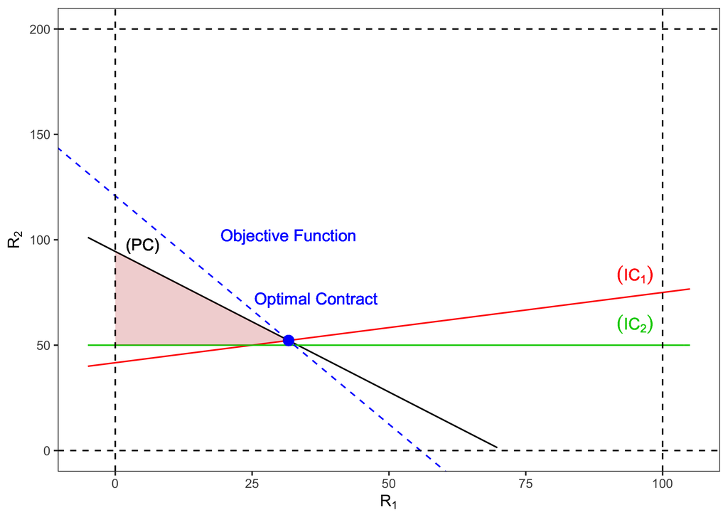

The blue point on the dashed blue line gives the highest objective value for the entrepreneur and the optimal contract is $R_b' = \{470/9, 95/3, 0\}$ in period 1. Please also note that this contract can be proposed by the Good type entrepreneur as well, given that this $R_b'$ contract and the original $R_b = \{R_2, 0, 0\}$ contract are indifferent to the Good type entreprenur.

##### 2.3 Analyses in Period 1

Given the optimal contract identified in 2.2 Visualize Optimal Contract in Period 1, we now need to uncover the true constraints and analyse accordingly.

###### * Entrepreneur’s Objective Function

Because of adverse selection, there is a mismatch between the constraints considered by the investors, when they decide the contract to finance the project, and the true constraints. Therefore, it is unknown whether the entrepreneur will choose to shirk on both projects or just one. If we assume that exerting the maxmium effort is optimal for the entrepreneur, we have shown in 2.2 Visualize Optimal Contract in Period 1 that the optimal contract is $R_b' = \{R_2', R_1', 0\} = \{470/9, 95/3, 0\}$. Then if we assume that the optimal action for the entrepreneur is to shirk on both projects (i.e. $E = 0$), the objective function in the optimization problem will be
$$\max_{R_b(r)} \sum_{r \in \Omega} R_b(r) \color{red}{\mathbf{P}(r | E =
0)} + \color{red}{2B}. \quad \tag{6}$$
And if we translate such an objective function into a line in the two dimensional graph - $(R_1, R_2) \in [0, R] \times [0, 2R]$, the line can be rewritten as
$$R_2 = - \frac{2 p_L (1-p_L)}{p_L^2} R_1 + c = - \frac{2 (1-p_L) p_H}{p_L
p_H} R_1 + c \text{, where } c \text{ is a constant.} \tag{7}$$
And comparing with Eq (4), we can see that $- \frac{2 (1-p_L) p_H}{p_L p_H} < - \frac{p_H (1-p_L) + (1-p_H) p_L}{p_H p_L} < - \frac{2 (1-p_H)}{p_H}$. This intuitively indicates that the contract $R_b' = \{R_2', R_1', 0\}$ will still be the unique optimal contract for the entrepreneur. Therefore, we can conclude that this contract $R_b' = \{R_2', R_1', 0\}$ will be optimal independent to entrepreneur’s action. But the action choice of the entrepreneur will be collectively determined by the agency rent and the private benefits. The following graph will support the previous arguments.

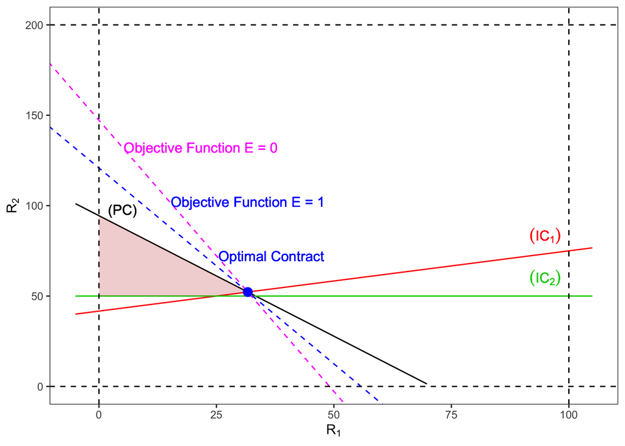

And it is clear that we can find out the action $E^*$ taken by the entrepreneur with this contract $R_b'$ is
$$E^* = \arg \max_{E \in \{0, 1, 2\}} \Big \{ \max \{\sum_{r \in \Omega}
R_b'(r) \mathbf{P}(r | E = 1) + B \text{ , } \sum_{r \in \Omega}
R_b'(r) \mathbf{P}(r | E = 0) + 2B\} \Big \}$$
Since then agency rent also links to the private benefit $B$, we know the first and second components in the maximization function can also be rewritten as a function of $B$. In the above example, we know that the maximum utilities conditional on $E = 0$, $E = 1$ and $E = 2$ are 33.56, 34 and 34 respectively, and the manager will choose $\color{red}{E = 1}$ in this case. i.e. exerts effort on only one project. While the agency rent for the entrepreneur when managing only one project is 17. This is smaller than the expected utlity realised under the diversification and supports our previous assumption that the entrepreneur will only diversify if can obtain higher personal utility.

> **(The following argument needs more rigorous prove!)**

> The purpose of this section will be (1) find the close-form expression of the optimal contract (2) searching whether the following $\bar{B}$ exists.  
> Date: 2022-06-12

And we know (assume with confident at this stage) there exists a threshold $\bar{B}$ such that
$$E^* = \begin{cases}
1 \quad &\text{, if } B \leq \bar{B} \\
0 \quad &\text{, if } B > \bar{B}
\end{cases}$$
Intuitively speaking, this is not very clear to see, but we can continue our work, conditional on entrepreneur’s optimal action. But no matter the choice of action, the NPV of this combined project, managed by the Bad manager, will be smaller than that managed by a Good manager. And since the manager will only consider this diversification strategy if the utility is higher in this case.

###### * Investors’ Participation Constraints

> Please note that we will focus on the case that $E = E^* = 1$ in all following analyses.

Since the optimal contract binds the misspecified participation constraint Eq. (1), we have
$$\sum_{r \in \Omega} (r - R_b'(r)) \mathbf{P}(r | E = 2) = 2 (I - A).
\tag{8}$$
Now we consider the true NPV of investors’ investments and we can write it as
$$\sum_{r \in \Omega} (r - R_b'(r)) \mathbf{P}(r | E = E^*) - 2 (I -
A) = \sum_{r \in \Omega} (r - R_b'(r)) \Big [\mathbf{P}(r | E = E^*)
- \mathbf{P}(r | E = 2) \Big ], \tag{9}$$
where the second equality comes from Eq (9). And it is possible that the true NPV of investors’ investment be weakly smaller than 1.

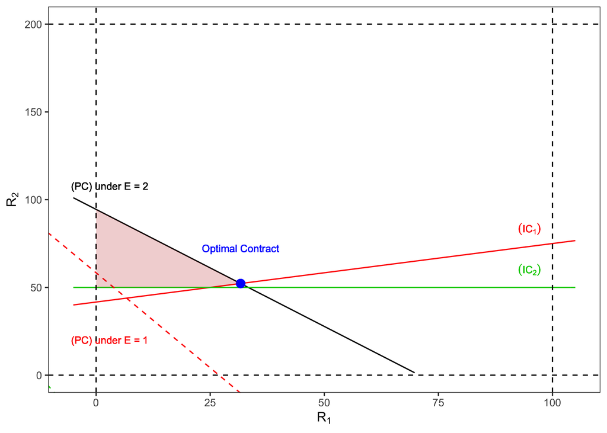

Still using the previous example, we plot the true binding PC constraints in the above graph. The red dashed line is the true binding PC constraints when the entrepreneur exerts effort on only one project, and the green dashed line is the true binding PC constraints under the entrepreneur shirking on both projects. And the NPV of investors’ investment is non-negative if and only if the optimal contract $R_b'$ lies in the area below the corresponding dashed line. In the above case, we know that NPVs of investors’ investments under $E = 1$ and $E = 0$ are -15 and -29.56 respectively. This is consistent with the red dashed line (PC under $E = 1$) and the green dashed line (PC under $E = 0$, not presented in the graph but is at the left bottom). However, this result is sensitive to the initial asset $A$ contributed by the entrepreneur and also $p_H$ and $p_L$. The purpose of this part is to demonstrate that such case exists.

> And with the assumption that the entrepreneur will take action $E = 1$ as a Bad type, the investors will be more likely to identify his/her skill type. This information can be incorporated into the signal $X_t$.

##### 2.4 Investors’ Belief Update

In this section, we analyse how the investors’ belief on the type of the entrepreneur changes at the beginning of period 2, given the signal $X_0$ at the end of period 1. The signal $X_0$ here assumes to be the only accessible information of the project towards investors and we define it to be the outcome of two projects, namely $2R$, $R$ or 0. i.e. $X_0 \in \{2R, R, 0\}$. We define the variable $T \in \{G, B\}$ as the type of the entrepreneur, where $G$ denotes the Good type and $B$ denotes the Bad type. And investors’ belief at the beginning of period 1 is
$$\mathbb{P}(T) = \begin{cases}
q \quad &\text{, if } T = G \\
1-q \quad &\text{, if } T = B,
\end{cases}$$
where $q > 0.5$. And
$$\mathbb{P}(X_0 | T = G) = \begin{cases}
p_H^2 &\text{, if } X_0 = 2R \\
2 p_H (1-pH) &\text{, if } X_0 = R \\
(1 - p_H)^2 &\text{, if } X_0 = 0.
\end{cases}$$
$$\text{ and }
\mathbb{P}(X_0 | T = B) = \begin{cases}
p_H p_L &\text{, if } X_0 = 2R \\
p_H (1-pL) + (1-p_H) p_L &\text{, if } X_0 = R \\
(1 - p_H)(1 - p_L) &\text{, if } X_0 = 0.
\end{cases}$$
The intuition here is that the probability distribution of the signal $X_0$, conditional on the manager being a Good type, is the same as the distribution of the project cash flow when the manager exerts efforts on both project. This relationship is determined by both the PC and two IC constraints when forming the contract. And align with our previous setting, the conditional probability distribution of $X_0$ for a Bad type manager is the distribution of the project cash flow when the manager exerts efforts on only one project.

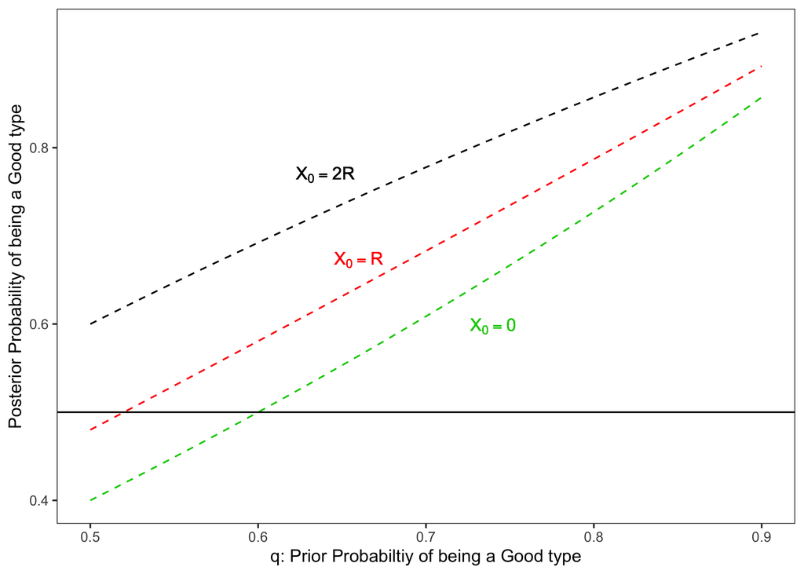

##### 2.5 Financing in Period 2

As shown in 2.4 Investors’ Belief Update, investors’ belief towards whether the manager is a Good type is updated when receiving the signal $X_0$. If the investors still identify the manager as a Good type, this company will continue to be financed and operate in Period 2. However, if the entrepreneur is identified as a Bad type, i.e. realizing the entrepreneur can exert effort on maximum one project, then the company may face financial constraints. And we will analyse this scenario.

First, we rewrite the optimization problem in the case that investors know the entrepreneur is a Bad type.
$$\max_{R_b(r)} \sum_{r \in \Omega} R_b(r) \mathbf{P}(r | E = 1) + {B}
\quad \text{ s.t. }$$
$$\text{(PC)} \quad \sum_{r \in \Omega} (r - R_b(r)) \mathbf{P}(r | E = 1)
\geq 2 (I - A) \tag{14}$$
$$\text{(IC)} \quad \sum_{r \in \Omega} R_b(r) \mathbf{P}(r | E = 1) + B
\geq
\sum_{r \in \Omega} R_b(r) \mathbf{P}(r | E = 0) + 2B$$
$$\Rightarrow
\sum_{r \in \Omega} R_b(r) \Big(\mathbf{P}(r | E = 1) - \mathbf{P}(r | E
= 0)\Big ) \geq B
\tag{15}$$
In this case, the investors will invest in the project if and only if the entrepreneur can be contracted and incentivized to prefer exerting efforts on one project than shirking on both. So, the objective function to the entrepreneur is conditional on $E = 1$ and the new (PC) and (IC) are formulated accordingly. Then from the (PC) and (IC) we have
$$\sum_{r \in \Omega} r \mathbf{P}(r | E = 1) - 2 (I - A) \geq \sum_{r \in
\Omega} R_b(r) \mathbf{P}(r | E = 1)$$
$$\text{and } \sum_{r \in \Omega} R_b(r) \mathbf{P}(r | E = 1)
\Big(\frac{\mathbf{P}(r | E = 1) - \mathbf{P}(r | E = 0)}{\mathbf{P}(r |
E = 1) }\Big ) = \sum_{r \in \Omega} R_b(r) \mathbf{P}(r | E = 1) L(r|E
= 1) \geq B,$$
where $L(r|E=1) = \frac{\mathbf{P}(r | E = 1) - \mathbf{P}(r | E = 0)}{\mathbf{P}(r | E = 1)}$ is the likelihood ratio. And let’s first use the previous example to see whether a contract can be formed in this case.

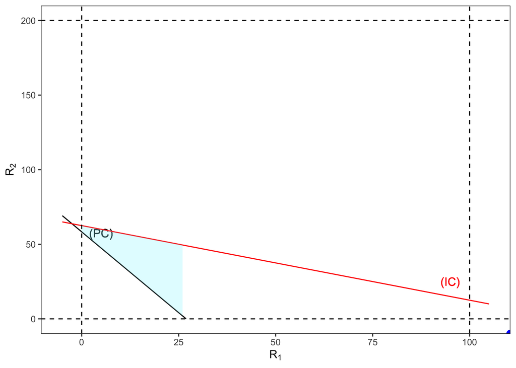

We can see that in this case, the entrepreneur faces financial constraints as no contract can satisfy both (PC) and (IC) and the company can no longer receive external financing.

Therefore, the entrepreneur faces the choice between spin-offs and raising funds throught other channels. The second option here may be to issue more equities, which was not incorporated in our initial setting. Here, just for simplicity, we consider only the first option. Once being identified as a Bad type, the entrepreneur can either keep the combined firm and face bankruptcy because of credit rationing, or spin off the firm and operate separately. It is clear to see that the entrepreneur will always choose the plan maximising the individual utility. And in this case, the first option, which leads to bankruptcy, gives a non-positive payoff towards the risk-neutral entrepreneur. While in the second option, the entrepreneur can choose to spin off the combined project into two independent and identical projects, as we assume at the very beginning of the project. In this case, the type of the entrepreneur will no longer influence the optimal contract and the entrepreneur can now manage only one of the project. The other project will be managed by a newly hire manager, but we assume the existing manager still receive the remainder of the project cash flow after deducting the debt repayment to investors and the minimum agenecy rent to the new manager. (*We also assume that the entrepreneur is protected by the limited liability in each project.*) After the spin-off, we denote the project maanged by the entrepreneur as project $a$ and the project managed by the new manager as proejct $b$. Based on our assumption at the very beginning 2.2 Visualize Optimal Contract in Period 1, where we purposefully set the amount of asset contributed by the entrepreneur in each project $A > \bar{A}$, both project $a$ and $b$ will receive external financing from the investors. And in project $a$, the agenecy rent to the entrepreneur is equivlent to the NPV of proejct $a$. And in project $b$, the entrepreneur, acting as an equity holder, expects to gain the NPV of project $b$ net the expected agency rent to the new manager. Therefore, the total amount of expected cash flow to the entrepreneur will be strictly positive in this setting, and agreeing a corproate spinoff is the optimal choice. Of course we can also consider the cost of spinoff $C$, and evaluate the trade-off between this cost to the entrepreneur (e.g. cost of hiring and public relation) and the benefit shown above. But this won’t necessary alter the logic of spin-offs we presented above.

> The analysis of the entrepreneur’s benefit in the project $b$ is only valid if the entrepreneur still owns the company. i.e. The contracts to investors and the new manager are determined by the entrepreneur. Then from the previous document with single project, we know that the expected cash flow to the entrepreneur is
> $$\max \Big \{ p_H R - I - p_H \frac{B}{\Delta p}, 0 \Big \}$$
> Please note that this value is sensitive to value of $A$, as it determines whether the NPV of the project is higher than the agency rent required. For instance, if $A = \bar{A}$, then this expected cash flow to the entrepreneur from project $b$ will be zero as well.

> Also, the new manager may not be the same as the entrepreneur in this case. If we denote the same of parameters for the new mamager as $\theta = \{p_H', p_L', \Delta p' = p_H' - p_L'\}$, the expected cash flow to the entrepreneur will be
> $$\max \Big \{ p_H' R - I - p_H' \frac{B}{\Delta p'}, 0 \Big
> \}.$$
> And the entrepreneur should always choose the manager who can generate the highest expected cash flow to the entrepreneur.

##### 2.6 Conclusion of the General Framework

The basic story of the previous analysis goes as this. The entrepreneur has two independent and identical projects. Both projects do not suffer from financial constraints, given the assets contributed by the entrepreneur. And now the entrepreneur wants to diversify and combines two projects into a single company. The entrepreneur can either be a Good or Bad type, but this information is unknown to investors. We assume that, at the first period, investors identify the entrepreneur as a Good type and finance the corresponding company. The entrepreneur can obtain a higher utility given this diversification, which consists the agency rent and the private benefit. At the end of the first period, investors receive a signal $X_0$ and they use it to update their beliefs about the type of entrepreneur. If they identify the entrepreneur as a Bad type, the entrepreneur may face financial constraints as they don’t have enough pledgeable income. Then at the beginning of the second period, the entrepreneur will choose to spin off the company into two, based on the projects, and continue to manage the old project $a$ and hire a new manager for the other project $b$. This corporate spin-off leads to a utility gain comparing to the case of bankruptcy, in the absence of the cost of spin-offs.

#### 3. Math Model

Following the logic presented in 2.6 Conclusion of the General Framework, we can build up the mathematical model.

##### 3.1 General Assumptions

Denote the two independent and identical projects as $a$ and $b$ and the entity combining two projects is called “the company”. The effort level of the entrepreneur is denoted as $E$. We set $E \in \{0,1\}$ when the entrepreneur runs only one project and $E=1$ means that the entrepreneur exerts high effort, while $E=0$ means the entrepreneur shirks. And $E \in \{0, 1, 2\}$ when the entrepreneur manages the company with each value corresponding to shirk on both projects, exert efforts on only one projects and exert efforts on both projects. The asset contributed by the entrepreneur to each project is $A \geq \bar{A} = I - p_H(R - \frac{B}{\Delta p})$ and the total investment for each project if $I$. In addition, for each project, the probability of success and generating cash flow $R$ is $p_H$ when the entrepreneur exerts effort on that project and $p_L$ if the entrepreneur shirks. And $p_H R \geq I \geq p_L R$. The private benefit for the entrepreneur in this case equals to $B(2-E)$ when $E \in \{0,1,2\}$.

The entrepreneur can be either a Good type or a Bad type. The difference is that the Good type does not have an upper bound for the effort level $E$, while the Bad type has an upper bound $\bar{E}$ such that $E \leq \bar{E}$. For simplicity, we set $\bar{E}=1$ meaning that the Bad type entrepreneur can only exert efforts on maximum one project. But for the Good type, she can choose to exert efforts on both projects. Meanwhile, we assume that a signal $X_0$, which is the only information regarding the company operation, will be received at the end of period 1. And we define $X_0$ as the success and failure outcome of each project. The investors with a prior - the probability of the entrepreneur being a Good type - can update their beliefs conditional on the signal $X_0$ they received at the end of period 1. And they will use the posterior to judge whether the entrepreneur is still a Good type or should be identified as a Bad type. (*Practically, the judgement can be subject to the posterior and some exogenous thresholds*.)

The whole projects live for two periods - period 1 and period 2. At the beginning of each period, the entrepreneur needs to seek financing for the company/projects. In period 1, she needs to decide whether she wants to diversify by adding project $b$ and operate the new company as a combination of project $a$ and $b$. And in period 2, she needs to decide whether to keep company’s current structure, or conduct a corporate spin-off, breaking the company into two new entities based upon project $a$ and $b$.

##### 3.2 When Does the Entrepreneur Choose to Diversify?

The decision of diversification depends on two factors. First, whether the manager can achieve a higher utility by diversification. Second, whether the company after the diversification can receive external financing from investors.

For the first factor, we know that the entrepreneur’s utility is $p_H R-I+A$ when managing only project $a$. So the diversification will happen if and only if the utility from managing the company is higher than that from managing project $a$. If the entrepreneur is a Good type and investors identify she as a Good type, from the analysis in Tirole (2006), we know that the entrepreneur’s utility will be $2(p_H - I + A)$ with the optimal contract $R_b = \{R_2, 0, 0\}$ corresponding to cash flow outcomes $\{2R,R,0\}$. We, however, are interested in the case that the entrepreneur is a Bad type and is misidentified by investors as a Good type. We are trying to find out the necessary conditions for the entrepreneur choosing to diversify.

> PS: The case that the entrepreneur is a Bad type and investors correctly identify her type is discussed in the case in period 2.

This question can be set up like this, under the assumption that $E=1$ is the entrepreneur’s optimal action,
$$\max_{R_b(r)} \sum_{r \in \Omega} R_b(r) \color{red}{\mathbf{P}(r | E =
1)} + \color{red}{B} \quad \text{ s.t. }$$
$$\text{(PC)} \quad \sum_{r \in \Omega} (r - R_b(r)) \mathbf{P}(r | E = 2)
\geq 2 (I - A) \tag{16}$$
$$\text{(} \text{IC}_1 \text{)} \quad \sum_{r \in \Omega} R_b(r)
\mathbf{P}(r | E = 2) \geq
\sum_{r \in \Omega} R_b(r) \mathbf{P}(r | E = 1) + B \tag{17}$$
$$\text{(} \text{IC}_2 \text{)} \quad \sum_{r \in \Omega} R_b(r)
\mathbf{P}(r | E = 2) \geq
\sum_{r \in \Omega} R_b(r) \mathbf{P}(r | E = 0) + 2B \tag{18}$$

And we can write out the Lagrangian as

$$\mathcal{L} = \sum_{r \in \Omega} R_b(r) \mathbf{P}(r | E = 1) + B +
\lambda_{PC} \Big \{ \sum_{r \in \Omega} (r - R_b(r)) \mathbf{P}(r | E =
2) - 2 (I - A) \Big \}$$
$$+ \lambda_{IC1} \Big \{ \sum_{r \in \Omega} R_b(r) \big [\mathbf{P}(r |
E = 2) - \mathbf{P}(r | E = 1) \big ] - B
\Big \}$$
$$+ \lambda_{IC2} \Big \{ \sum_{r \in \Omega} R_b(r) \big [\mathbf{P}(r |
E = 2) - \mathbf{P}(r | E = 0) \big ] - 2B
\Big \} \tag{19}$$

FOC:
$$\frac{\partial \mathcal{L}}{\partial R_b(r)} = \mathbf{P}(r|E=1) -
\lambda_{PC} \big \{ \mathbf{P}(r|E=2) \big \}
+ \lambda_{IC1} \big \{ \mathbf{P}(r|E=2) - \mathbf{P}(r|E=1) \big \}$$
$$+ \lambda_{IC2} \big \{ \mathbf{P}(r|E=2) - \mathbf{P}(r|E=0) \big \} =
0, \quad \forall r \in \{2R, R, 0\} \tag{20}$$
From the FOC we can see that if (PC) does not bind, we must have $\lambda_{PC} = 0$ and we have $\frac{\partial \mathcal{L}}{\partial R_b(r)} > 0$ for all potential contract $R_b \in [0, 2R] \times [0, R] \times \{0\}$. Therefore, (PC) must bind. Then, does the contract in the form of $\{R_2, 0, 0\}$ solve the question? No, it will not satisfy the FOC condition. And the only solution we can find is the optimal contract in the form of $R_b' = \{R_2, R_1, 0\}$, where
$$R_2 = 2R - \frac{2(I-A) - (R - R_1) \mathbf{P}(R | E = 2)}{\mathbf{P}(2R
| E = 2)} \quad \text{ and } \quad
R_1 = \min \big \{ R_1^1, R_1^2 \big \}$$
with $R_1^1$ coming from binding both (PC) and (IC<sub>1</sub>) and $R_1^2$ coming from binding both (PC) and (IC<sub>2</sub>) constraints. Previous graphical presentation will be an intuitive way to verify the this contract.

Meanwhile, we can set up the question when shirking on both projects (i.e. $E = 0$) being the optimal action for the entrepreneur as
$$\max_{R_b(r)} \sum_{r \in \Omega} R_b(r) \color{red}{\mathbf{P}(r | E =
0)} + \color{red}{2B} \quad \text{ s.t. }$$
$$\text{(PC)} \quad \sum_{r \in \Omega} (r - R_b(r)) \mathbf{P}(r | E = 2)
\geq 2 (I - A) \tag{21}$$
$$\text{(} \text{IC}_1 \text{)} \quad \sum_{r \in \Omega} R_b(r)
\mathbf{P}(r | E = 2) \geq
\sum_{r \in \Omega} R_b(r) \mathbf{P}(r | E = 1) + B \tag{22}$$
$$\text{(} \text{IC}_2 \text{)} \quad \sum_{r \in \Omega} R_b(r)
\mathbf{P}(r | E = 2) \geq
\sum_{r \in \Omega} R_b(r) \mathbf{P}(r | E = 0) + 2B \tag{23}$$
Undergoing the same procedure, we can verify that $R_b' = \{R_2, R_1, 0\}$ will be the optimal contract given $E=0$ being entrepreneur’s optimal action. Therefore, $R_b' = \{R_2, R_1, 0\}$ will the optimal contract, regardless of the optimal action for a Bad type entrepreneur in this case. And with this unique contract, we can define the optimal action of the entrepreneur is
$$E^* = \arg \max_{E \in \{0,1\}} \sum_{r \in \Omega} R_b'(r)
\mathbf{P}(r | E) + (2-E)B.$$
We can see that $E^* = 1$ if
$$\sum_{r \in \Omega} R_b'(r) \mathbf{P}(r | E = 1) + B \geq \sum_{r
\in \Omega} R_b'(r) \mathbf{P}(r | E = 0) + 2B$$
$$\iff \sum_{r \in \Omega} R_b'(r) \mathbf{P}(r | E = 2)
\frac{\mathbf{P}(r | E = 1) - \mathbf{P}(r | E = 0)}{\mathbf{P}(r | E =
2)}$$
$$= \sum_{r \in \Omega} R_b'(r) \mathbf{P}(r | E = 2) \Bigg [ -
\frac{\mathbf{P}(r | E = 2) - \mathbf{P}(r | E = 1)}{\mathbf{P}(r | E =
2)} + \frac{\mathbf{P}(r | E = 2) - \mathbf{P}(r | E = 0)}{\mathbf{P}(r
| E = 2)} \Bigg ] \geq B \tag{23}$$
Since the optimal contract satisfies (PC), (IC<sub>1</sub>) and (IC<sub>2</sub>) constraints, we can get from (IC<sub>1</sub>) and (IC<sub>2</sub>) that
$$\sum_{r \in \Omega} R_b'(r) \mathbf{P}(r | E = 2) \Bigg
[\frac{\mathbf{P}(r | E = 2) - \mathbf{P}(r | E = 1)}{\mathbf{P}(r | E =
2)} \Bigg ] \geq B$$
$$\text{and } \sum_{r \in \Omega} R_b'(r) \mathbf{P}(r | E = 2) \Bigg
[\frac{\mathbf{P}(r | E = 2) - \mathbf{P}(r | E = 0)}{\mathbf{P}(r | E =
2)} \Bigg ] \geq 2B.$$
And if $R_1 = R_1^1 \leq R_1^2$, then we know (PC) and (IC<sub>1</sub>) bind but (IC<sub>2</sub>) does not. And bring this information back to Eq (23), we know that the inequality holds and $E^* = 1$ is the optimal action to the entrepreneur. And if And if $R_1 = R_1^2 > R_1^1$, meaning that (PC) and (IC<sub>2</sub>) bind but not (IC<sub>1</sub>), we can see that the inequality does not hold and $E^* = 0$.

Please note that although the exact action chosen by the entrepreneur in period 1 will alter the distribution of the cash flow outcome and the signal $X_0$, it won’t impact investors’ financing decisions as long as they still identify the entrepreneur as a Good type.

> This may come into play when we switch from a binary identification process to a more realistic case. In that scenario, we consider investors will incorporate their objective beliefs on the type of the entrepreneur into forming the financial contract.

##### 3.3 What if the Bad Type Mimics the Good Type?

In the previous analysis, we can see that both contract $R_b = \{R_2, 0, 0\}$ and $R_b' = \{R_2, R_1, 0\}$ (*Sorry for abusing the variable here. Just be clear that the $R_2$ term in the two contracts are not the same in value.*) are optimal contracts for a Good type entrepreneur. While, only the latter, $R_b'$, is optimal to the Bad type entrepreneur. Therefore, the Good type should always choose $R_b$ as a way to signal her type, conditional on all entrepreneurs maximizing their objective functions. So, the sensible thing for a Bad type entrepreneur to do is to mimic the optimal contract of the Good type entrepreneur $R_b$.

Now the question turns into

1. what is the necessary condition for the entrepreneur choosing to diversify?
2. what is the optimal action of the entrepreneur, if the diversification proceeds?

For the first question, the contract proposed by a Bad type entrepreneur will be $R_b = \{R_2, 0, 0\}$, same as the one proposed by a Good type entrepreneur. And given the (PC) binds, we have
$$(2R - R_2) p_H^2 + 2R p_H (1-p_H) = 2(I-A) \implies R_2 = \frac{2[p_H R
- (I-A)]}{p_H^2}. \tag{24}$$
So, the entrepreneur will only choose to diversify, if the utility generated from the contract $R_b$ is no smaller than that from managing only one project. Mathematically, we have that the diversification happens if
$$\max \big \{ p_H p_L R_2 + B, p_L^2 R_2 + 2B \big \} \geq p_H R - (I-A),$$
where the LHS is the maximum utility generated by the entrepreneur and the RHS is the maximum utility of the entrepreneur when managing only one project.

Meanwhile, the optimal action in the second question can be determined as
$$E^* = \begin{cases}
1 \quad \text{, if } p_H p_L R_2 + B \geq p_L^2 R_2 + 2B\\
0 \quad \text{, if } p_H p_L R_2 + B < p_L^2 R_2 + 2B
\end{cases}$$

Now let’s see what is the NPV of investors’ investments. With the contract $R_b$, we have the true expected payoff towards investors as
$$(2R - R_2) p_H p_L + R [p_H (1-p_L) + (1-p_H) p_L] = R \Big ( p_H + p_L
- 2 p_L \Big ) + \frac{2 p_L}{p_H} \Big (I-A \Big ),$$
which will be larger than $2(I-A)$ (i.e. generating positive NPV) if $p_H R \geq 2(I-A)$.

> Issue of Mimicking the Contract.

##### 3.4 How Do Investors Update Their Beliefs?